# Multivariate stats

Robert W Schlegel

2018-01-19

> To err is human, but to really foul things up you need a computer.

> —*Paul R. Ehrlich*

# Introduction

In this brief tutorial we are going to walk through the steps necessary to perform a most basic ordination. We will be using MDS for this as it produces, in my opinion, the most straight forward results. There is of course an entire school of thought on this and I, a mere climate scientists, am in no way an authoritative voice on the matter.

```r
# Load libraries
library(tidyverse)
library(vegan)

# Load built-in data
data("dune")
data("dune.env")
```

# MDS

MDS, or multi-dimensional scaling, is high level clustering technique. MDS allows us to determine which of the abiotic variables in our dataset are having the most pronounced effects on the clustering of the dunes. Running an MDS on a data frame in R is simple as the `vegan` package will do all of the heavy lifting for us. First we will jump straight in and run an MDS, then we will take a step back and try changing the standardisation of the values and the distance matrix that we would normally need to first calculate. Please consult the help file (`?metaMDS`) for details on the function.

```r
dune_MDS <- metaMDS(dune, autotransform = F)
```

Or we may be more specific in the way in which we prepare our data for the MDS.

```r
# Standardise data
dune_stand <- decostand(dune, method = "standardize")

# Create Bray-Curtis dissimilarity matrix
dune_dist <- vegdist(dune, method = "bray")

# Create distance matrix
dune_MDS <- metaMDS(dune_dist)
```

```
R> Run 0 stress 0.1192678
R> Run 1 stress 0.1192684
R> ... Procrustes: rmse 0.0004147155  max resid 0.001275698
R> ... Similar to previous best
R> Run 2 stress 0.1183186
R> ... New best solution
R> ... Procrustes: rmse 0.02026993  max resid 0.06495456
R> Run 3 stress 0.1192678
R> Run 4 stress 0.1192679
R> Run 5 stress 0.1192679
R> Run 6 stress 0.1183187
R> ... Procrustes: rmse 0.0001779624  max resid 0.000584988
R> ... Similar to previous best
R> Run 7 stress 0.1808911
R> Run 8 stress 0.3769383
R> Run 9 stress 0.1192681
R> Run 10 stress 0.1183186
R> ... Procrustes: rmse 7.081203e-05  max resid 0.0002385526
R> ... Similar to previous best
R> Run 11 stress 0.1808913
R> Run 12 stress 0.1192678
R> Run 13 stress 0.1192681
R> Run 14 stress 0.1192679
R> Run 15 stress 0.1192681
R> Run 16 stress 0.1809578
R> Run 17 stress 0.1192678
R> Run 18 stress 0.1183186
R> ... Procrustes: rmse 3.763228e-05  max resid 0.0001221875
R> ... Similar to previous best
R> Run 19 stress 0.1982896
R> Run 20 stress 0.1183186
R> ... Procrustes: rmse 6.609037e-05  max resid 0.0002147018
R> ... Similar to previous best
R> *** Solution reached
```

# Stress

No, not that stress. We are talking about the stress of the MDS model now. This is an important value to check. If the stress is high (>0.3) the MDS model is doing a poor job of modeling the dissimilarities in the data. If it is low (<0.1) the model is doing a very good job of displaying the relationships within the data. To check the stress of our results we use the following line of code.

```r
dune_MDS$stress
```

```
R> [1] 0.1183186
```

What is the stress of this model? Is that an acceptable level?

# Basic biplot

With the MDS calculated, and the stress tested, it’s time to visualise the first round of results.

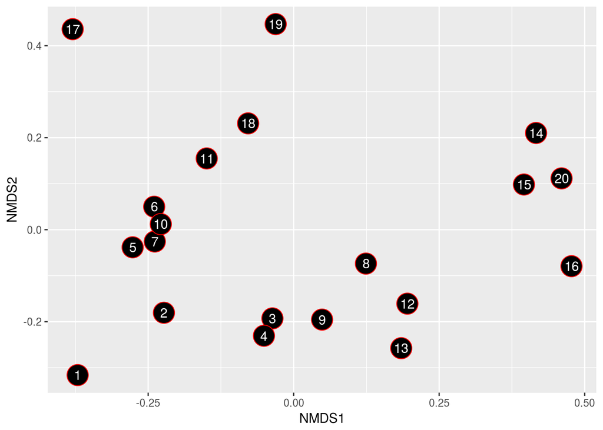

The basic biplot of our dune results.

```r
# Convert for ggplot
dune_MDS_points <- data.frame(site = 1:nrow(dune)) %>%
  mutate(x = as.numeric(dune_MDS$points[ ,1]),
         y = as.numeric(dune_MDS$points[ ,2]))

# Visualise with ggplot
ggplot(data = dune_MDS_points, aes(x = x, y = y)) +
  geom_point(size = 8, shape = 21, fill = "black", colour = "red") +
  geom_text(aes(label = site), colour = "white") +
  labs(x = "NMDS1", y = "NMDS2")
```

# Fitting environmental variables

As with all of the other ordination analyses we have performed in R thus far, fitting environmental variables may also be done with one easy step. We do this by providing the `envfit()` function with a formula, the same as we do for linear models. The dependent variable (to the left of the `~`) will be the results of the MDS on the species assemblage data, and the independent variables (to the right of the `~`) are the columns from our environmental variables data frame.

```r
dune_envfit <- envfit(dune_MDS ~ Moisture + Use, data = dune.env)
dune_envfit
```

```
R>
R> ***FACTORS:
R>
R> Centroids:
R>               NMDS1   NMDS2
R> Moisture1   -0.2252 -0.0178
R> Moisture2   -0.1739  0.0061
R> Moisture4    0.1221 -0.1781
R> Moisture5    0.2897  0.0652
R> UseHayfield -0.0692  0.1434
R> UseHaypastu -0.0182 -0.1488
R> UsePasture   0.1260  0.0373
R>
R> Goodness of fit:
R>              r2 Pr(>r)
R> Moisture 0.5014  0.001 ***
R> Use      0.1871  0.134
R> ---
R> Signif. codes:  0 '***' 0.001 '**' 0.01 '*' 0.05 '.' 0.1 ' ' 1
R> Permutation: free
R> Number of permutations: 999
```

In the printout above we see the results for the R^2 (here r2) and *p*-values for the fit of each abiotic variable to the species assemblage data. Which relationships are significant? Which variable(s) appears to best explain the variance in the species assemblages? Which of the axes of the MDS have the strongest relationship with which variable?

To plot the results of our fitted abiotic variables on top of our species MDS we need to quickly prep it to play nice with **`ggplot2`** and then we need only append a couple of lines onto the chunk we wrote to display our MDS results.

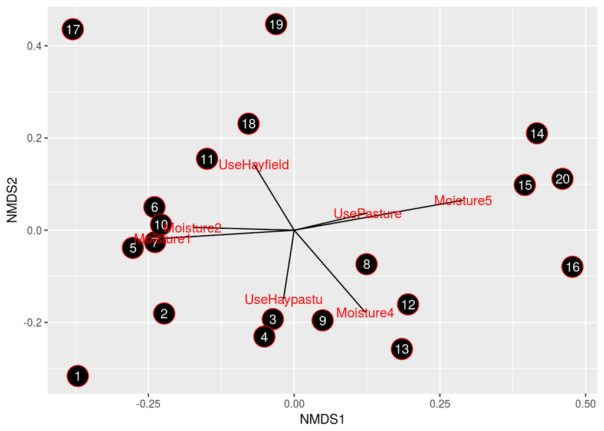

```r
# Extract the envfit vector values
dune_envfit_df <- data.frame(dune_envfit$factors$centroids) %>%
  mutate(factors = row.names(.)) %>%
  rename(x = NMDS1, y = NMDS2)

# Visualise environmental fits
ggplot(data = dune_MDS_points, aes(x = x, y = y)) +
  geom_point(size = 8, shape = 21, fill = "black", colour = "red") +
  geom_text(aes(label = site), colour = "white") +
  geom_segment(data = dune_envfit_df,
               aes(x = 0, y = 0, xend = x, yend = y)) +
  geom_text(data = dune_envfit_df, colour = "red",
            aes(x = x, y = y, label = factors)) +
  labs(x = "NMDS1", y = "NMDS2")
```

# Diversity

If we are interested in calculating a Shannon-Wiener index on the species diversity found within the dunes we need only one function.

```r
diversity(dune)
```

```
R>        1        2        3        4        5        6        7        8
R> 1.440482 2.252516 2.193749 2.426779 2.544421 2.345946 2.471733 2.434898
R>        9       10       11       12       13       14       15       16
R> 2.493568 2.398613 2.106065 2.114495 2.099638 1.863680 1.979309 1.959795
R>       17       18       19       20
R> 1.876274 2.079387 2.134024 2.048270
```

# ANOSIM

One final thing. It is also necessary to know if any differences exist between the clusters we have determined for our data. To do this we use the `anosim()` function from the `vegan` package.

```r
# Create dendrogram
dune_clust <- hclust(dune_dist, "ward.D")

# Extract clusters
dune_grp <- cutree(dune_clust, 4)

# Calculate ANOSIM
anosim(dune_dist, dune_grp)
```

```
R>
R> Call:
R> anosim(dat = dune_dist, grouping = dune_grp)
R> Dissimilarity: bray
R>
R> ANOSIM statistic R: 0.8226
R>       Significance: 0.001
R>
R> Permutation: free
R> Number of permutations: 999
```